# Homework 1

Hierachial Modeling and Longitudinal Data Analysis

# Question 1

**Coronary bypass surgery is a major surgical procedure that is often performed on older adults with heart conditions. Recovery time from the surgery varies, and is potentially associated with age. The state regulations and hospital practices on the procedure also vary, and may affect the recovery time. You have a dataset on recovery time. Model recovery time appropriately, and analyze the data with all the statistical tools you have learned, and study what effects recovery time. The data are at the file recovery.csv at the Folder “Datasets” under the “Files” Section**

### Data checking

```
##   Paitent.ID Hospital State Age..years. Recovery.time..days.
## 1          1     NYPB    NY          72                   71
## 2          2     NYPB    NY          81                   66
## 3          3     NYPB    NY          77                   67
## 4          4     NYPB    NY          78                   57
## 5          5     NYPB    NY          88                   66
## 6          6     NYPB    NY          80                   68
```

```
## 'data.frame':    120 obs. of  5 variables:
##  $ Paitent.ID          : int  1 2 3 4 5 6 7 8 9 10 ...
##  $ Hospital            : Factor w/ 12 levels "DH","HH","HUMC",..: 7 7 7 7 7 7 8 8 8 8 ...
##  $ State               : Factor w/ 3 levels "CT","NJ","NY": 3 3 3 3 3 3 3 3 3 3 ...
##  $ Age..years.         : int  72 81 77 78 88 80 76 82 82 77 ...
##  $ Recovery.time..days.: int  71 66 67 57 66 68 62 60 67 64 ...
```

```
## [1] 0
```

#### mean recovery time by hospital by state

| state | hospital | mean | sd | median | q1 | q3 |
| --- | --- | --- | --- | --- | --- | --- |
| CT | DH | 62.222 | 6.534 | 64.0 | 61.00 | 65.00 |
| CT | HH | 62.889 | 7.688 | 61.0 | 60.00 | 71.00 |
| CT | SFMC | 64.200 | 6.477 | 65.5 | 58.50 | 68.25 |
| CT | YNH | 62.167 | 4.535 | 62.0 | 59.25 | 66.25 |
| NJ | HUMC | 61.214 | 6.129 | 59.0 | 57.25 | 63.75 |
| NJ | JSU | 62.556 | 8.445 | 62.0 | 57.25 | 66.00 |
| NJ | MMC | 62.167 | 6.242 | 64.5 | 57.75 | 66.75 |
| NJ | RWJU | 60.143 | 6.012 | 60.0 | 56.00 | 63.00 |
| NY | LIJ | 63.333 | 10.281 | 62.0 | 57.00 | 67.25 |
| NY | NYPB | 65.833 | 4.708 | 66.5 | 66.00 | 67.75 |
| NY | NYUL | 62.200 | 6.125 | 62.0 | 58.50 | 64.00 |
| NY | URMC | 61.077 | 4.890 | 61.0 | 58.00 | 64.00 |

#### Boxplot of recovery time

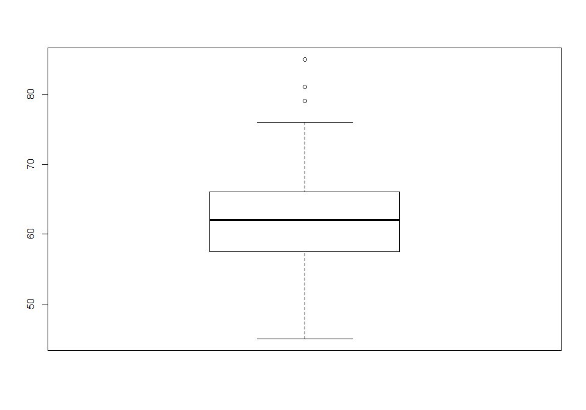

#### plot

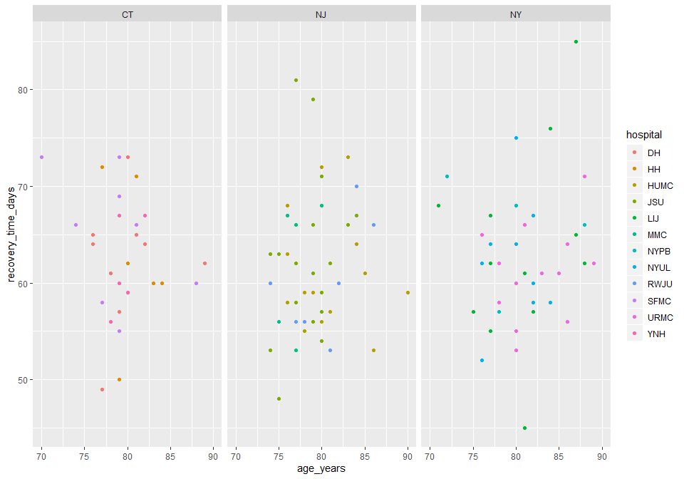

### Model Building

#### Model 1

Random intercept on hospital nested within state mixed model controlling for age as fixed effect

*Results*: Random intercept mixed model controlling for age as fixed effect and clustered by state and hospital nested within state is fitted. There is no variance explained by state/hospital random effect and model is singular fit. The fixed effect age and intercept has a correlation of almost -1. This suggested that the model is overfitted and random effect component it too complex to be estimated using the data.

```
## Linear mixed model fit by REML. t-tests use Satterthwaite's method [
## lmerModLmerTest]
## Formula: recovery_time_days ~ age_years + (1 | state/hospital)
##    Data: recovery_dat
##
## REML criterion at convergence: 799.9
##
## Scaled residuals:
##     Min      1Q  Median      3Q     Max
## -2.5772 -0.7085 -0.1260  0.5855  3.1865
##
## Random effects:
##  Groups         Name        Variance Std.Dev.
##  hospital:state (Intercept)  0.00    0.000
##  state          (Intercept)  0.00    0.000
##  Residual                   46.36    6.809
## Number of obs: 120, groups:  hospital:state, 12; state, 3
##
## Fixed effects:
##             Estimate Std. Error       df t value Pr(>|t|)
## (Intercept)  52.3254    12.4155 118.0000   4.215 4.93e-05 ***
## age_years     0.1262     0.1552 118.0000   0.813    0.418
## ---
## Signif. codes:  0 '***' 0.001 '**' 0.01 '*' 0.05 '.' 0.1 ' ' 1
##
## Correlation of Fixed Effects:
##           (Intr)
## age_years -0.999
## convergence code: 0
## boundary (singular) fit: see ?isSingular
```

#### Model 1 Assumptions

**Results**: The residuals are normally distributed (from shapiro test). Residuals are randomly scattered, does not show any deviation from linear form and shows constant variation across fitted range.

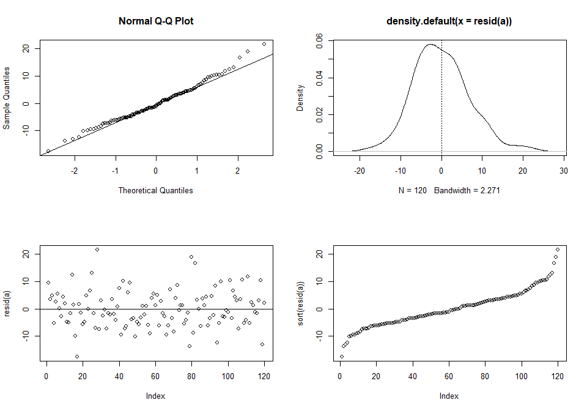

```
##
##  Shapiro-Wilk normality test
##
## data:  resid(a)
## W = 0.98538, p-value = 0.2224
```

#### Model 1a

- Random intercept on nested mixed model controlling for age as fixed effect removing global intercept.

```
## Linear mixed model fit by REML. t-tests use Satterthwaite's method [
## lmerModLmerTest]
## Formula: recovery_time_days ~ -1 + age_years + (1 | state/hospital)
##    Data: recovery_dat
##
## REML criterion at convergence: 823.5
##
## Scaled residuals:
##     Min      1Q  Median      3Q     Max
## -2.4936 -0.6979 -0.1631  0.7317  2.8853
##
## Random effects:
##  Groups         Name        Variance Std.Dev.
##  hospital:state (Intercept)  0.00    0.000
##  state          (Intercept)  0.00    0.000
##  Residual                   52.89    7.272
## Number of obs: 120, groups:  hospital:state, 12; state, 3
##
## Fixed effects:
##            Estimate Std. Error        df t value Pr(>|t|)
## age_years 7.794e-01  8.299e-03 1.190e+02   93.92   <2e-16 ***
## ---
## Signif. codes:  0 '***' 0.001 '**' 0.01 '*' 0.05 '.' 0.1 ' ' 1
## convergence code: 0
## boundary (singular) fit: see ?isSingular
```

#### Model 1a Assumptions

**Results**: The residuals are normally distributed (from shapiro test). Residuals are randomly scattered, does not show any deviation from linear form and shows constant variation across fitted range.

```
##
##  Shapiro-Wilk normality test
##
## data:  resid(a1)
## W = 0.9815, p-value = 0.09825
```

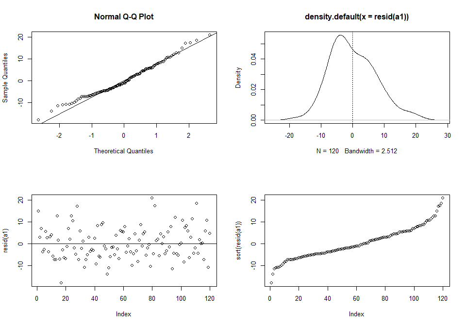

#### Model 2

random intercept nested mixed model controlling for age and state as fixed effects.

```
## Linear mixed model fit by REML. t-tests use Satterthwaite's method [
## lmerModLmerTest]
## Formula: recovery_time_days ~ state + age_years + (1 | state/hospital)
##    Data: recovery_dat
##
## REML criterion at convergence: 794.1
##
## Scaled residuals:
##     Min      1Q  Median      3Q     Max
## -2.5859 -0.7080 -0.1255  0.5703  3.1524
##
## Random effects:
##  Groups         Name        Variance Std.Dev.
##  hospital:state (Intercept)  0.0000  0.0000
##  state          (Intercept)  0.3732  0.6109
##  Residual                   46.8887  6.8475
## Number of obs: 120, groups:  hospital:state, 12; state, 3
##
## Fixed effects:
##             Estimate Std. Error       df t value Pr(>|t|)
## (Intercept)  53.6192    12.7207 116.0000   4.215 4.97e-05 ***
## stateNJ      -1.2363     1.7800 116.0000  -0.695    0.489
## stateNY      -0.4468     1.8250 116.0000  -0.245    0.807
## age_years     0.1177     0.1593 116.0000   0.739    0.461
## ---
## Signif. codes:  0 '***' 0.001 '**' 0.01 '*' 0.05 '.' 0.1 ' ' 1
##
## Correlation of Fixed Effects:
##           (Intr) statNJ statNY
## stateNJ   -0.095
## stateNY    0.060  0.537
## age_years -0.995  0.018 -0.136
## convergence code: 0
## boundary (singular) fit: see ?isSingular
```

#### Model 2 Assumptions

**Results**: The residuals are normally distributed (from shapiro test). Residuals are randomly scattered, does not show any deviation from linear form and shows constant variation across fitted range.

```
##
##  Shapiro-Wilk normality test
##
## data:  resid(c)
## W = 0.98282, p-value = 0.1299
```

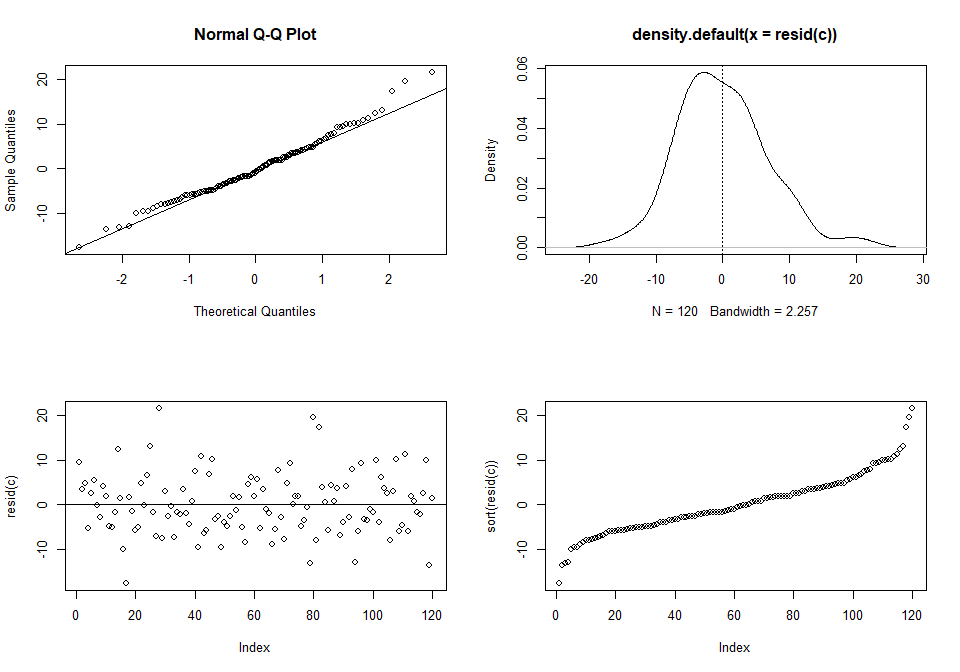

#### AICs

```
##    df      AIC
## a   5 809.9161
## a1  4 831.4738
## c   7 808.1046
```

### Results

- **model specifications**:
  - $\alpha$ : overall mean
  - $\beta_1$: age fixed effect
  - $\beta_2$: state fixed effect
  - $\gamma_j \sim N(0, \sigma_{\gamma}^2)$: state random main effect
  - $\delta_{j(k)} \sim N(0, \sigma_{\delta}^2)$: hospital random effect nested within state
  - $e_{ijk} \sim N(0, \sigma_{e}^2)$: Error
  - model 1: $y_{ijk}= \alpha+ \beta_1 Age_i + \gamma_j + \delta_{j(k)}+ e_{ijk}$
  - model 1a: $y_{ijk}= \beta_1 Age_i + \gamma_j + \delta_{j(k)}+ e_{ijk}$
  - model 2: $y_{ijk}= \alpha+ \beta_1 Age_i + \beta_2 state_i+ \gamma_j + d_{j(k)}+ e_{ijk}$

Based on lowest AIC value, model 2: random intercept nested mixed model controlling for Age and State fixed effects are preferred. Model suggests little variances explained by state random effect (0.3732). There is no statistically significant age effect on recovery time as noted by the estimate and p value (est=0.1177; p=0.461).

# Question 2

**Some Type II Diabetes patients are going through negative life changes, which is likely to raise their blood sugar level. You have data on A1C (a measure of average blood sugar over months) as the patients go through negative life changes. Build a quadratic growth model based using random effects. The data are at the file A1Cq.csv at the Folder “Datasets” under the “Files” Section.**

```
##   Patient  A1C Time
## 1       1 7.55    3
## 2       1 8.05   18
## 3       1 8.05   24
## 4       1 8.25   27
## 5       1 8.05   39
## 6       1 8.25   48
```

```
## 'data.frame':    60 obs. of  3 variables:
##  $ Patient: int  1 1 1 1 1 1 2 2 2 2 ...
##  $ A1C    : num  7.55 8.05 8.05 8.25 8.05 8.25 8.2 8.5 8.5 8.7 ...
##  $ Time   : int  3 18 24 27 39 48 9 24 30 36 ...
```

```
## [1] 0
```

### Data Checking

| patient | mean | sd | median | q1 | q3 |
| --- | --- | --- | --- | --- | --- |
| 1 | 8.033 | 0.256 | 8.05 | 8.050 | 8.200 |
| 2 | 8.483 | 0.160 | 8.50 | 8.500 | 8.500 |
| 3 | 8.400 | 0.341 | 8.40 | 8.125 | 8.675 |
| 4 | 8.183 | 0.242 | 8.20 | 8.150 | 8.325 |
| 5 | 8.500 | 0.303 | 8.60 | 8.525 | 8.675 |
| 6 | 8.283 | 0.151 | 8.25 | 8.150 | 8.425 |
| 7 | 8.383 | 0.204 | 8.40 | 8.400 | 8.475 |
| 8 | 8.283 | 0.264 | 8.20 | 8.100 | 8.525 |
| 9 | 8.567 | 0.333 | 8.70 | 8.325 | 8.775 |
| 10 | 8.150 | 0.297 | 8.25 | 8.025 | 8.325 |

#### Boxplot of a1c values

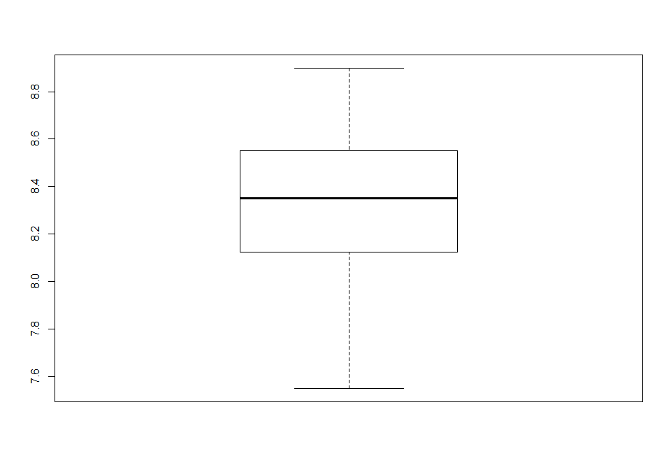

#### Spaghetti plot

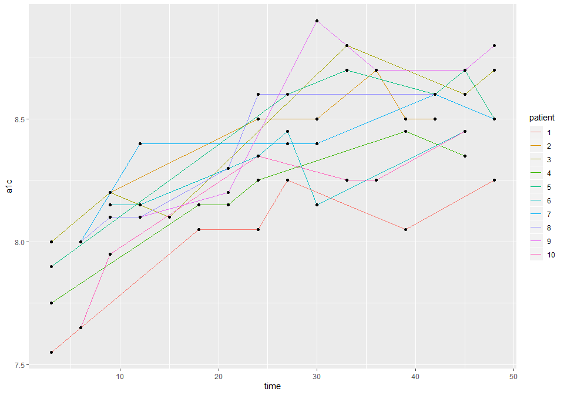

#### linear time

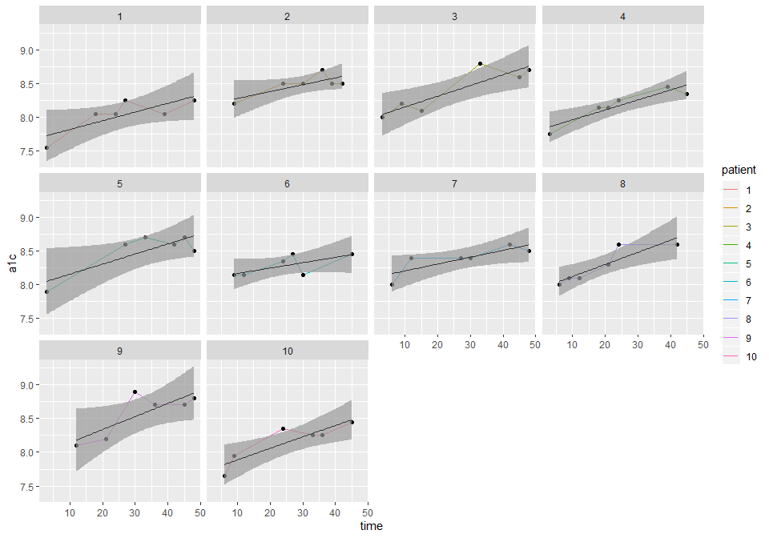

#### quadratic time

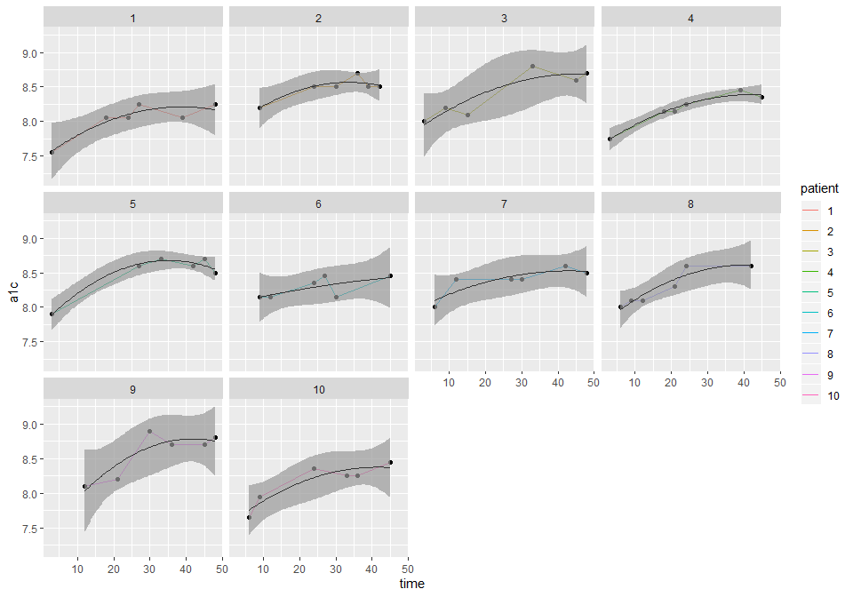

### Model Building

#### Model 1

- Random intercept model controlling for linear and quadratic time effects.

```
## Linear mixed model fit by REML. t-tests use Satterthwaite's method [
## lmerModLmerTest]
## Formula: a1c ~ time + I(time^2) + (1 | patient)
##    Data: aicq_dat
##
## REML criterion at convergence: -29.3
##
## Scaled residuals:
##      Min       1Q   Median       3Q      Max
## -2.20760 -0.55937  0.06125  0.53305  2.43445
##
## Random effects:
##  Groups   Name        Variance Std.Dev.
##  patient  (Intercept) 0.01942  0.1394
##  Residual             0.01529  0.1237
## Number of obs: 60, groups:  patient, 10
##
## Fixed effects:
##               Estimate Std. Error         df t value Pr(>|t|)
## (Intercept)  7.737e+00  7.051e-02  3.500e+01 109.722  < 2e-16 ***
## time         3.719e-02  4.926e-03  4.883e+01   7.549 9.60e-10 ***
## I(time^2)   -4.398e-04  9.241e-05  4.891e+01  -4.760 1.76e-05 ***
## ---
## Signif. codes:  0 '***' 0.001 '**' 0.01 '*' 0.05 '.' 0.1 ' ' 1
##
## Correlation of Fixed Effects:
##           (Intr) time
## time      -0.692
## I(time^2)  0.607 -0.973
```

#### Model 1 Assumptions

**Results**: The residuals are normally distributed (from shapiro test). Residuals are randomly scattered, does not show any deviation from linear form and shows constant variation across fitted range.

```
##
##  Shapiro-Wilk normality test
##
## data:  resid(a)
## W = 0.9871, p-value = 0.7779
```

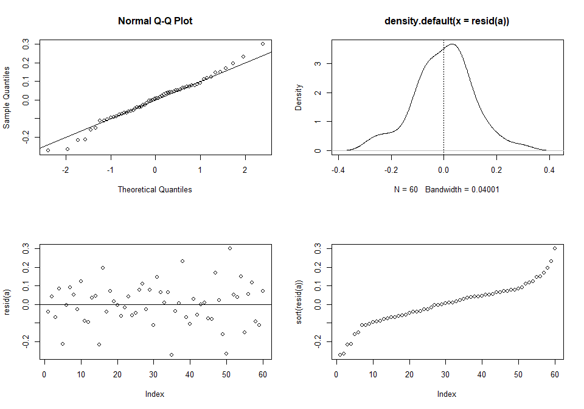

#### Model 2

- Random intercept and slope model controlling for linear and quadratic time effects.

```
## Linear mixed model fit by REML. t-tests use Satterthwaite's method [
## lmerModLmerTest]
## Formula: a1c ~ time + I(time^2) + (time | patient)
##    Data: aicq_dat
##
## REML criterion at convergence: -30.4
##
## Scaled residuals:
##      Min       1Q   Median       3Q      Max
## -2.17444 -0.60793  0.08631  0.54420  2.37534
##
## Random effects:
##  Groups   Name        Variance  Std.Dev. Corr
##  patient  (Intercept) 1.104e-02 0.105066
##           time        1.625e-06 0.001275 1.00
##  Residual             1.492e-02 0.122144
## Number of obs: 60, groups:  patient, 10
##
## Fixed effects:
##               Estimate Std. Error         df t value Pr(>|t|)
## (Intercept)  7.731e+00  6.347e-02  2.615e+01 121.810  < 2e-16 ***
## time         3.775e-02  4.871e-03  4.936e+01   7.749 4.42e-10 ***
## I(time^2)   -4.514e-04  9.129e-05  4.888e+01  -4.945 9.39e-06 ***
## ---
## Signif. codes:  0 '***' 0.001 '**' 0.01 '*' 0.05 '.' 0.1 ' ' 1
##
## Correlation of Fixed Effects:
##           (Intr) time
## time      -0.708
## I(time^2)  0.661 -0.969
## convergence code: 0
## boundary (singular) fit: see ?isSingular
```

#### Model 2 Assumptions

**Results**: The residuals are normally distributed (from shapiro test). Residuals are randomly scattered, does not show any deviation from linear form and shows constant variation across fitted range.

```
##
##  Shapiro-Wilk normality test
##
## data:  resid(b)
## W = 0.98792, p-value = 0.8177
```

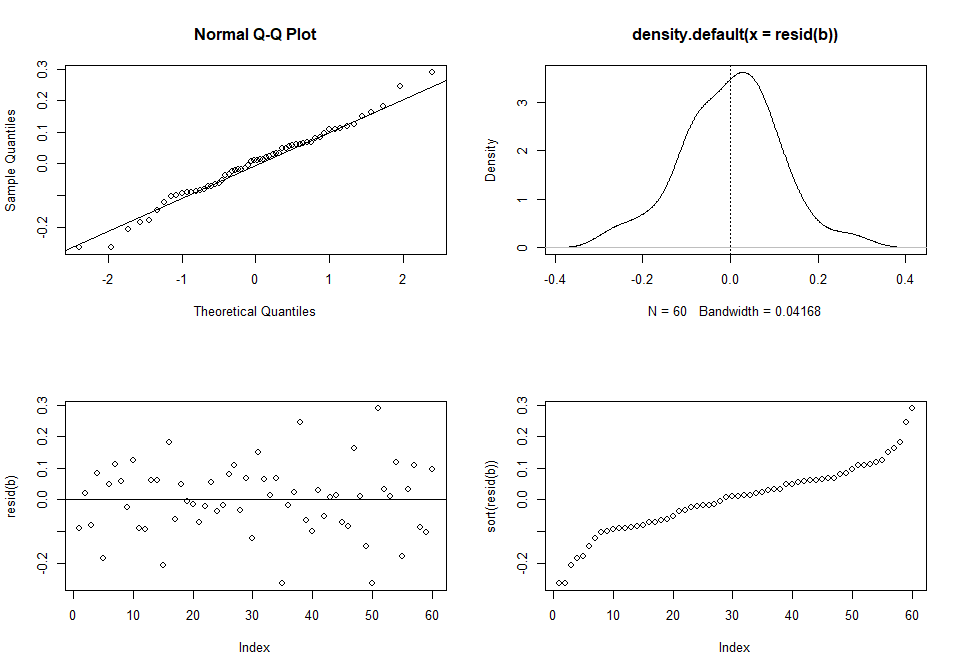

#### Model 3

```
## Linear mixed model fit by REML. t-tests use Satterthwaite's method [
## lmerModLmerTest]
## Formula: a1c ~ time + I(time^2) + (time + I(time^2) | patient)
##    Data: aicq_dat
##
## REML criterion at convergence: -21.3
##
## Scaled residuals:
##      Min       1Q   Median       3Q      Max
## -2.52853 -0.52748  0.05672  0.55139  2.01509
##
## Random effects:
##  Groups   Name        Variance  Std.Dev. Corr
##  patient  (Intercept) 1.273e-02 0.11284
##           time        5.287e-04 0.02299  -0.68
##           I(time^2)   1.296e-07 0.00036   0.68 -1.00
##  Residual             1.411e-02 0.11877
## Number of obs: 60, groups:  patient, 10
##
## Fixed effects:
##               Estimate Std. Error         df t value Pr(>|t|)
## (Intercept)  7.7207444  0.0642335 45.9179417 120.198  < 2e-16 ***
## time         0.0388487  0.0086909 49.0436857   4.470 4.63e-05 ***
## I(time^2)   -0.0004704  0.0001446 13.5085194  -3.253  0.00602 **
## ---
## Signif. codes:  0 '***' 0.001 '**' 0.01 '*' 0.05 '.' 0.1 ' ' 1
##
## Correlation of Fixed Effects:
##           (Intr) time
## time      -0.718
## I(time^2)  0.695 -0.987
## convergence code: 0
## boundary (singular) fit: see ?isSingular
```

#### Model 3 Assumptions

**Results**: The residuals are normally distributed (from shapiro test). Residuals are randomly scattered, does not show any deviation from linear form and shows constant variation across fitted range.

```
##
##  Shapiro-Wilk normality test
##
## data:  resid(c)
## W = 0.98246, p-value = 0.5409
```

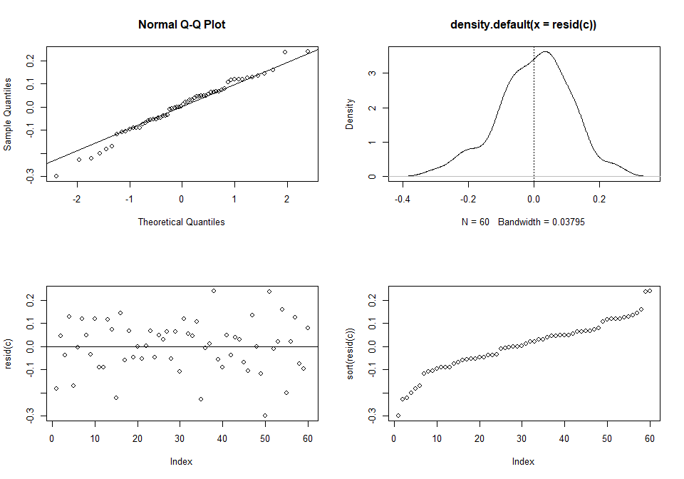

#### AICs

```
## Data: aicq_dat
## Models:
## a: a1c ~ time + I(time^2) + (1 | patient)
## b: a1c ~ time + I(time^2) + (time | patient)
## c: a1c ~ time + I(time^2) + (time + I(time^2) | patient)
##   Df     AIC     BIC logLik deviance  Chisq Chi Df Pr(>Chisq)
## a  5 -52.111 -41.639 31.055  -62.111
## b  7 -49.244 -34.584 31.622  -63.244 1.1336      2     0.5673
## c 10 -43.220 -22.276 31.610  -63.220 0.0000      3     1.0000
```

### Results

Based on lowest AIC value, model 1: random intercept mixed model controlling for linear and quadratic fixed effects are preferred. Model suggests more than half of variances were explained by random effect (0.0194). There is statistically significant linear (est=3.719e-02; p<0.0001) and quadratic time effect (est=-4.398e-04; p<0.0001) on a1c as noted by the estimate and p value respectively. This suggested that patient’s a1c level increase over time but the rate of increase declines overtime.